# Deseq2

### Step 3

Run Deseq2 on object to find differential gene expression. Here we are comparing drought vs. pre-drought across all time points

```r
dds <- DESeq(dds)
resultsNames(dds) # lists the coefficients
```

```
## [1] "Intercept"                       "Condition_Drought_vs_PreDrought"
## [3] "Site_Site2_vs_Site1"             "Site_Site3_vs_Site1"
```

```r
##drought vs predrought time 0
res <- results(dds, contrast = c("Condition","Drought","PreDrought"))
plotMA(res, ylim=c(-40,40))
```

[output not shown]

```r
summary(res)
```

```
##
## out of 7414 with nonzero total read count
## adjusted p-value < 0.1
## LFC > 0 (up)       : 568, 7.7%
## LFC < 0 (down)     : 388, 5.2%
## outliers [1]       : 779, 11%
## low counts [2]     : 2865, 39%
## (mean count < 2)
## [1] see 'cooksCutoff' argument of ?results
## [2] see 'independentFiltering' argument of ?results
```

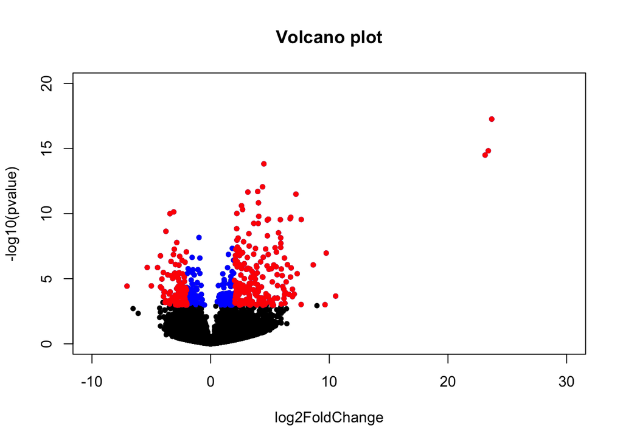

```r
#make volcano plot
#reset par
par(mfrow=c(1,1))
# Make a basic volcano plot
with(res, plot(log2FoldChange, -log10(pvalue), pch=20, main="Volcano plot", xlim=c(-10,30), ylim=c(0,20)))

# Add colored points: blue if padj<0.01, red if log2FC>1 and padj<0.05)
with(subset(res, padj<.01 ), points(log2FoldChange, -log10(pvalue), pch=20, col="blue"))
with(subset(res, padj<.01 & abs(log2FoldChange)>2), points(log2FoldChange, -log10(pvalue), pch=20, col="red"))
```

Shrink effect size using apeglm. Notice spread of log2FC decreases without the extreme outliers of log2FC > 20.

```r
#shrink effect size
resLFC <- lfcShrink(dds, coef="Condition_Drought_vs_PreDrought", type="apeglm")
```

```
## using 'apeglm' for LFC shrinkage. If used in published research, please cite:
##     Zhu, A., Ibrahim, J.G., Love, M.I. (2018) Heavy-tailed prior distributions for
##     sequence count data: removing the noise and preserving large differences.
##     Bioinformatics. https://doi.org/10.1093/bioinformatics/bty895
```

```r
resLFC
```

```
## log2 fold change (MAP): Condition Drought vs PreDrought
## Wald test p-value: Condition Drought vs PreDrought
## DataFrame with 7414 rows and 5 columns
##             baseMean log2FoldChange     lfcSE      pvalue        padj
##            <numeric>      <numeric> <numeric>   <numeric>   <numeric>
## KO:K00001  85.720271      0.1564256  0.422342    0.664312    0.804257
## KO:K00002   1.288149      0.0816016  0.810781          NA          NA
## KO:K00003 356.903899      0.4829826  0.680902          NA          NA
## KO:K00004   2.052021     -0.1510241  0.739513    0.586056          NA
## KO:K00005   0.295115     -0.0841371  0.810240    0.607315          NA
## ...              ...            ...       ...         ...         ...
## KO:K19784 119.271817      1.9438230  0.414382 3.61016e-07 2.00152e-05
## KO:K19786   0.471282      0.0902579  0.811528          NA          NA
## KO:K19788   2.042808      0.2785595  0.871585 1.39914e-01          NA
## KO:K19789   0.170424     -0.1324025  0.817197 6.72673e-01          NA
## KO:K19791   0.490408      0.1041752  0.802896 7.04116e-01          NA
```

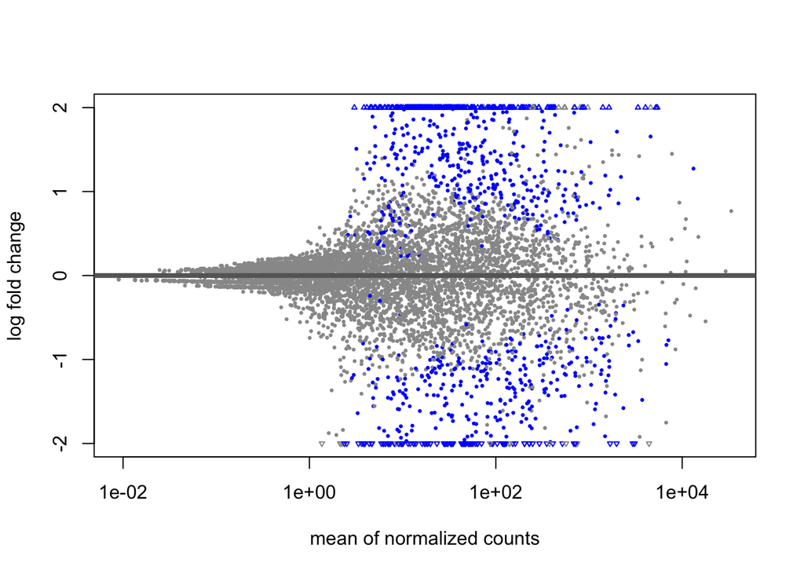

```r
plotMA(resLFC, ylim=c(-2,2))
```

```r
summary(resLFC)
```

```
##
## out of 7414 with nonzero total read count
## adjusted p-value < 0.1
## LFC > 0 (up)       : 568, 7.7%
## LFC < 0 (down)     : 388, 5.2%
## outliers [1]       : 779, 11%
## low counts [2]     : 2865, 39%
## (mean count < 2)
## [1] see 'cooksCutoff' argument of ?results
## [2] see 'independentFiltering' argument of ?results
```

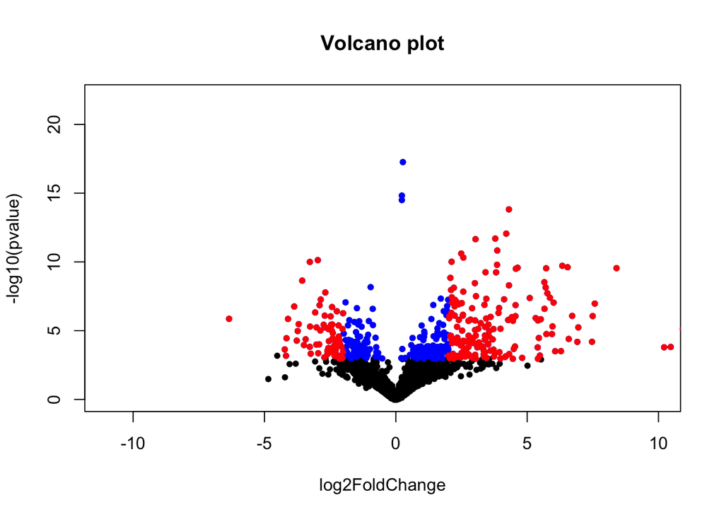

```r
#make volcano plot
#reset par
par(mfrow=c(1,1))

# Make a basic volcano plot
with(resLFC, plot(log2FoldChange, -log10(pvalue), pch=20, main="Volcano plot", xlim=c(-11,10), ylim=c(0,22)))
with(subset(resLFC, padj<.01 ), points(log2FoldChange, -log10(pvalue), pch=20, col="blue"))
with(subset(resLFC, padj<.01 & abs(log2FoldChange)>2), points(log2FoldChange, -log10(pvalue), pch=20, col="red"))
```

## Drought vs. Pre-drought across different time points. Here, pre-drought 0hr is set as reference.)

### Step 1

Create deseq2 object

```r
###create a deseq2 object with Condition, Time, and Site as design###
coldata$Condition_Time <- factor(coldata$Condition_Time, c("PreDrought_0hr", "PreDrought_6hr", "PreDrought_48hr",
                                                           "Drought_0hr", "Drought_6hr", "Drought_48hr"))

coldata$Condition_Time <- relevel(coldata$Condition_Time, ref = "PreDrought_0hr")


dds <- DESeqDataSetFromMatrix(countData = cts,
                              colData = coldata,
                              design= ~ Condition_Time + Site)
```

### Step 2

Explore data using variance stabilization normalization (VST) transformation

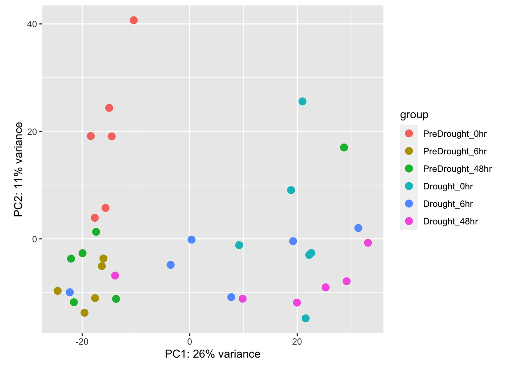

```r
vstcounts <- vst(dds, blind=TRUE)
vst.export<- assay(vstcounts)
vst.export<- as.data.frame(vst.export)

plotPCA(vstcounts, intgroup=c("Condition_Time"))
```

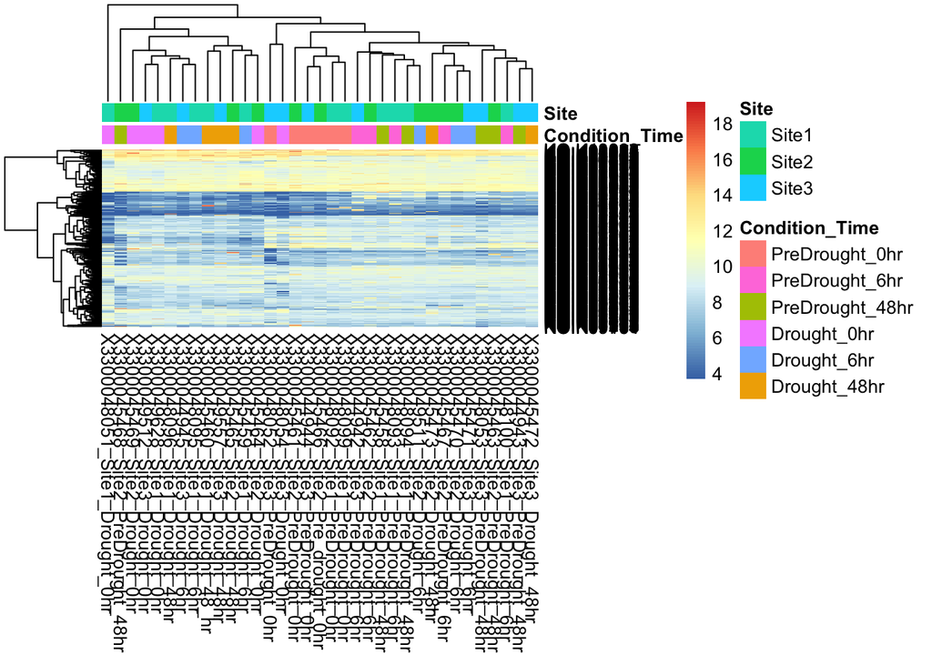

```r
select <- order(rowMeans(counts(dds)),
                decreasing=TRUE)[1:500]
df <- as.data.frame(colData(dds)[,c("Condition_Time","Site")])


pheatmap(assay(vstcounts)[select,], cluster_rows=TRUE, show_rownames=TRUE,
         cluster_cols=TRUE, annotation_col=df)
```

### Step 3a

Run Deseq2 on object to find differential gene expression. Here we are comparing Drought 0hr vs Pre-drought 0hr

```r
###deifferential expression analysis###

dds <- DESeq(dds)
resultsNames(dds) # lists the coefficients
```

```
## [1] "Intercept"
## [2] "Condition_Time_PreDrought_6hr_vs_PreDrought_0hr"
## [3] "Condition_Time_PreDrought_48hr_vs_PreDrought_0hr"
## [4] "Condition_Time_Drought_0hr_vs_PreDrought_0hr"
## [5] "Condition_Time_Drought_6hr_vs_PreDrought_0hr"
## [6] "Condition_Time_Drought_48hr_vs_PreDrought_0hr"
## [7] "Site_Site2_vs_Site1"
## [8] "Site_Site3_vs_Site1"
```

```r
##drought vs predrought time 0
res.T0 <- results(dds, contrast = c("Condition_Time","Drought_0hr","PreDrought_0hr"))
plotMA(res, ylim=c(-40,40))
```

[output not shown]

```r
summary(res.T0)
```

```
##
## out of 7414 with nonzero total read count
## adjusted p-value < 0.1
## LFC > 0 (up)       : 487, 6.6%
## LFC < 0 (down)     : 304, 4.1%
## outliers [1]       : 0, 0%
## low counts [2]     : 3737, 50%
## (mean count < 5)
## [1] see 'cooksCutoff' argument of ?results
## [2] see 'independentFiltering' argument of ?results
```

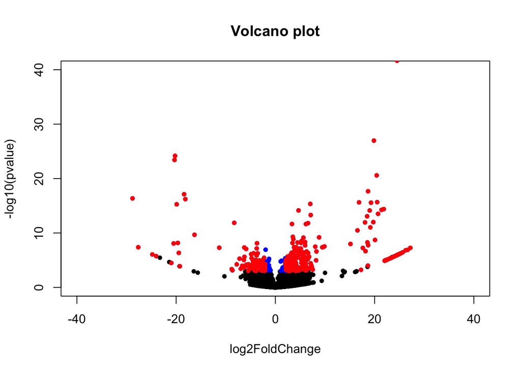

```r
#make volcano plot
#reset par
par(mfrow=c(1,1))
# Make a basic volcano plot
with(res.T0, plot(log2FoldChange, -log10(pvalue), pch=20, main="Volcano plot", xlim=c(-40,40), ylim=c(0,40)))

# Add colored points: blue if padj<0.01, red if log2FC>1 and padj<0.05)
with(subset(res.T0, padj<.01 ), points(log2FoldChange, -log10(pvalue), pch=20, col="blue"))
with(subset(res.T0, padj<.01 & abs(log2FoldChange)>2), points(log2FoldChange, -log10(pvalue), pch=20, col="red"))
```

### Step 3b

Shrink effect size using apeglm. Notice spread of log2FC decreases without the extreme outliers of log2FC > 20.

```r
#shrink effect size
resLFC.T0 <- lfcShrink(dds, coef="Condition_Time_Drought_0hr_vs_PreDrought_0hr", type="apeglm")
```

```
## using 'apeglm' for LFC shrinkage. If used in published research, please cite:
##     Zhu, A., Ibrahim, J.G., Love, M.I. (2018) Heavy-tailed prior distributions for
##     sequence count data: removing the noise and preserving large differences.
##     Bioinformatics. https://doi.org/10.1093/bioinformatics/bty895
```

```r
resLFC.T0
```

```
## log2 fold change (MAP): Condition Time Drought 0hr vs PreDrought 0hr
## Wald test p-value: Condition Time Drought 0hr vs PreDrought 0hr
## DataFrame with 7414 rows and 5 columns
##             baseMean log2FoldChange     lfcSE      pvalue        padj
##            <numeric>      <numeric> <numeric>   <numeric>   <numeric>
## KO:K00001  85.720271     0.31389099  0.667860    0.534226    0.736263
## KO:K00002   1.288149     0.12109723  1.025284    0.418603          NA
## KO:K00003 356.903899    -0.17527286  0.746987    0.739092    0.869368
## KO:K00004   2.052021    -0.12105846  1.017423    0.842776          NA
## KO:K00005   0.295115    -0.00703491  1.018698    0.974919          NA
## ...              ...            ...       ...         ...         ...
## KO:K19784 119.271817     2.84192793  0.633268 1.01521e-06 3.92942e-05
## KO:K19786   0.471282    -0.00746749  1.018721 9.71370e-01          NA
## KO:K19788   2.042808    -0.01503096  1.017542 9.68323e-01          NA
## KO:K19789   0.170424    -0.00705222  1.018538 9.70855e-01          NA
## KO:K19791   0.490408     0.04564141  1.014821 8.39107e-01          NA
```

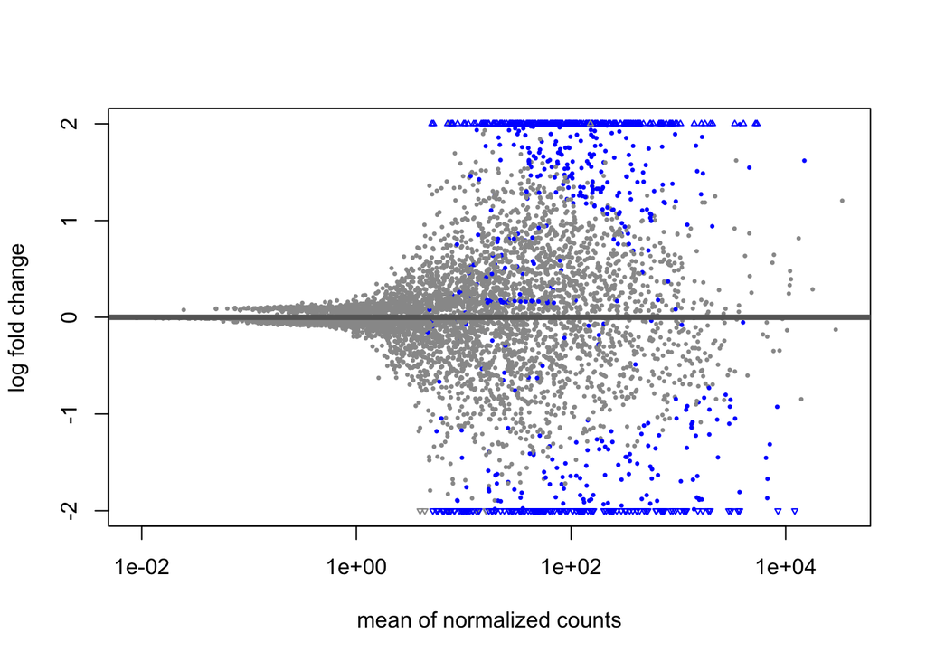

```r
plotMA(resLFC.T0, ylim=c(-2,2))
```

```r
summary(resLFC.T0)
```

[output not shown]

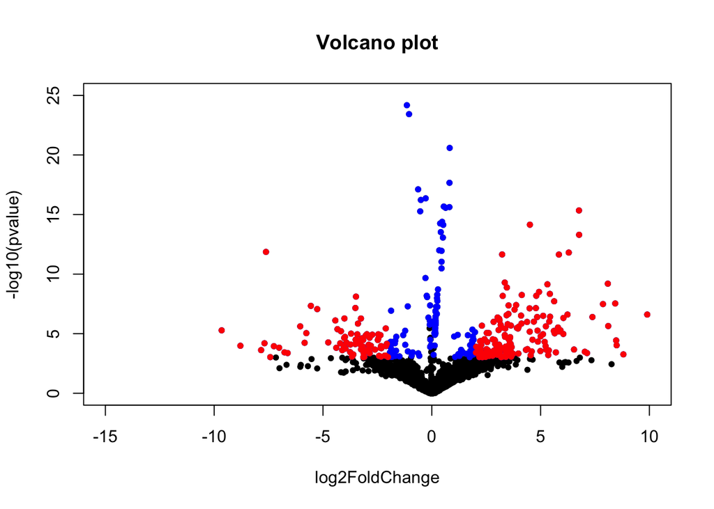

```r
#make volcano plot
#reset par
par(mfrow=c(1,1))
# Make a basic volcano plot
with(resLFC.T0, plot(log2FoldChange, -log10(pvalue), pch=20, main="Volcano plot", xlim=c(-15,10), ylim=c(0,25)))
with(subset(resLFC.T0, padj<.01 ), points(log2FoldChange, -log10(pvalue), pch=20, col="blue"))
with(subset(resLFC.T0, padj<.01 & abs(log2FoldChange)>2), points(log2FoldChange, -log10(pvalue), pch=20, col="red"))
```

## Drought vs. Pre-drought across different time points. (Here, pre-drought 6hr is set as reference.)

### Step 1

Create deseq2 object

```r
###create a deseq2 object with Condition, Time, and Site as design###
coldata$Condition_Time <- factor(coldata$Condition_Time, c("PreDrought_0hr", "PreDrought_6hr", "PreDrought_48hr",
                                                           "Drought_0hr", "Drought_6hr", "Drought_48hr"))

coldata$Condition_Time <- relevel(coldata$Condition_Time, ref = "PreDrought_6hr")


dds <- DESeqDataSetFromMatrix(countData = cts,
                              colData = coldata,
                              design= ~ Condition_Time + Site)
```

### Step 3a (Skip step 2, data exploration, because already performed above)

```r
dds <- DESeq(dds)
resultsNames(dds) # lists the coefficients
```

```
## [1] "Intercept"
## [2] "Condition_Time_PreDrought_0hr_vs_PreDrought_6hr"
## [3] "Condition_Time_PreDrought_48hr_vs_PreDrought_6hr"
## [4] "Condition_Time_Drought_0hr_vs_PreDrought_6hr"
## [5] "Condition_Time_Drought_6hr_vs_PreDrought_6hr"
## [6] "Condition_Time_Drought_48hr_vs_PreDrought_6hr"
## [7] "Site_Site2_vs_Site1"
## [8] "Site_Site3_vs_Site1"
```

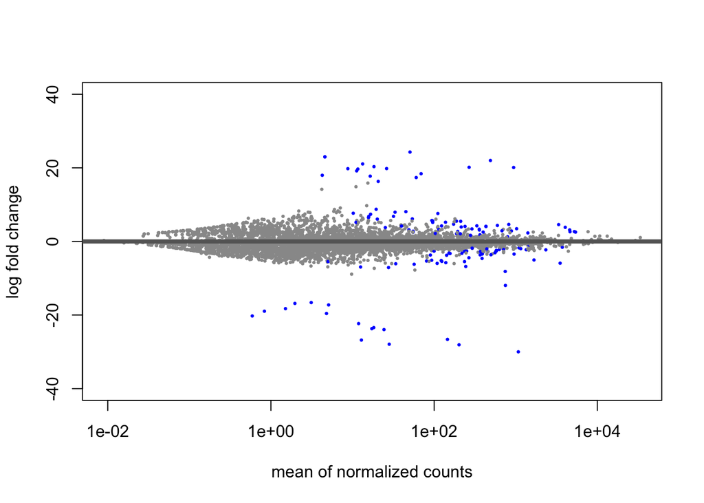

```r
res.T6 <- results(dds, contrast = c("Condition_Time","Drought_6hr","PreDrought_6hr"))
plotMA(res.T6, ylim=c(-40,40))
```

```r
summary(res.T6)
```

```
##
## out of 7414 with nonzero total read count
## adjusted p-value < 0.1
## LFC > 0 (up)       : 71, 0.96%
## LFC < 0 (down)     : 65, 0.88%
## outliers [1]       : 0, 0%
## low counts [2]     : 1869, 25%
## (mean count < 1)
## [1] see 'cooksCutoff' argument of ?results
## [2] see 'independentFiltering' argument of ?results
```

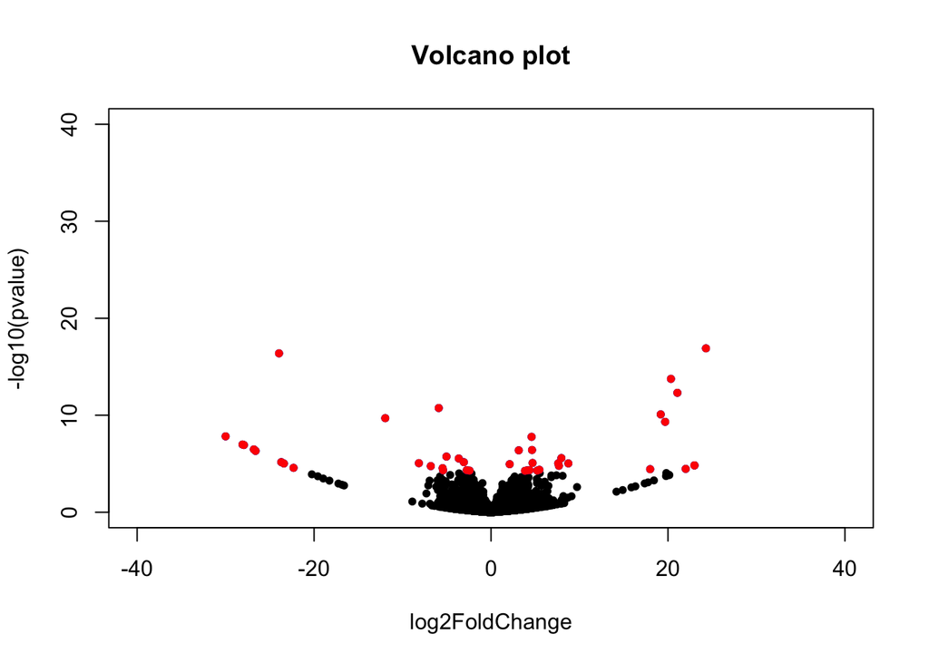

```r
#make volcano plot
#reset par
par(mfrow=c(1,1))
# Make a basic volcano plot
with(res.T6, plot(log2FoldChange, -log10(pvalue), pch=20, main="Volcano plot", xlim=c(-40,40), ylim=c(0,40)))

# Add colored points: blue if padj<0.01, red if log2FC>1 and padj<0.05)
with(subset(res.T6, padj<.01 ), points(log2FoldChange, -log10(pvalue), pch=20, col="blue"))
with(subset(res.T6, padj<.01 & abs(log2FoldChange)>2), points(log2FoldChange, -log10(pvalue), pch=20, col="red"))
```

### Step 3b Shrink effect size using apeglm. Notice spread of log2FC decreases without the extreme outliers of log2FC > 20.

```r
#shrink effect size
resLFC.T6 <- lfcShrink(dds, coef="Condition_Time_Drought_6hr_vs_PreDrought_6hr", type="apeglm")
```

```
## using 'apeglm' for LFC shrinkage. If used in published research, please cite:
##     Zhu, A., Ibrahim, J.G., Love, M.I. (2018) Heavy-tailed prior distributions for
##     sequence count data: removing the noise and preserving large differences.
##     Bioinformatics. https://doi.org/10.1093/bioinformatics/bty895
```

```r
resLFC.T6
```

```
## log2 fold change (MAP): Condition Time Drought 6hr vs PreDrought 6hr
## Wald test p-value: Condition Time Drought 6hr vs PreDrought 6hr
## DataFrame with 7414 rows and 5 columns
##             baseMean log2FoldChange     lfcSE     pvalue      padj
##            <numeric>      <numeric> <numeric>  <numeric> <numeric>
## KO:K00001  85.720271    -0.01245470  0.346029 0.94096521 0.9991054
## KO:K00002   1.288149    -0.00232462  0.378484 0.83606852 0.9991054
## KO:K00003 356.903899     0.30242223  0.570818 0.00224017 0.0938401
## KO:K00004   2.052021    -0.03674447  0.379667 0.53710070 0.9991054
## KO:K00005   0.295115    -0.00132191  0.378505 0.83935443        NA
## ...              ...            ...       ...        ...       ...
## KO:K19784 119.271817     0.77020840  0.808572  0.0178582  0.424994
## KO:K19786   0.471282    -0.00130855  0.378505  0.8479350        NA
## KO:K19788   2.042808    -0.00990113  0.378529  0.7694871  0.999105
## KO:K19789   0.170424    -0.00139629  0.378490  0.8511124        NA
## KO:K19791   0.490408    -0.00776977  0.378493  0.8610557        NA
```

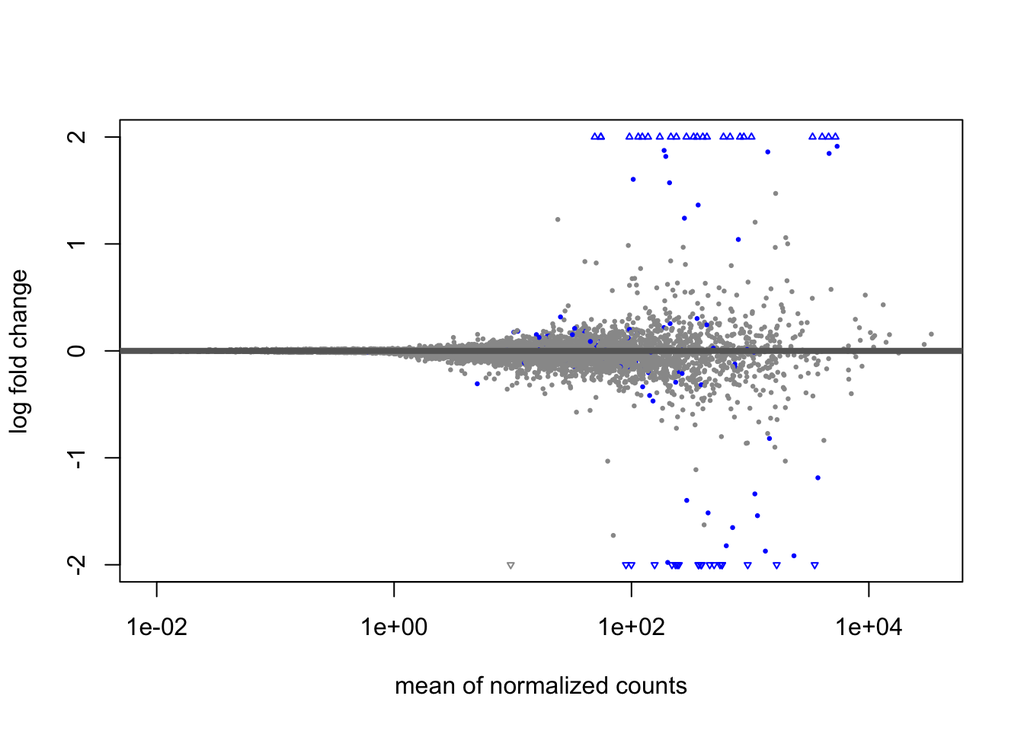

```r
plotMA(resLFC.T6, ylim=c(-2,2))
```

```r
summary(resLFC.T6)
```

```
##
## out of 7414 with nonzero total read count
## adjusted p-value < 0.1
## LFC > 0 (up)       : 71, 0.96%
## LFC < 0 (down)     : 65, 0.88%
## outliers [1]       : 0, 0%
## low counts [2]     : 1869, 25%
## (mean count < 1)
## [1] see 'cooksCutoff' argument of ?results
## [2] see 'independentFiltering' argument of ?results
```

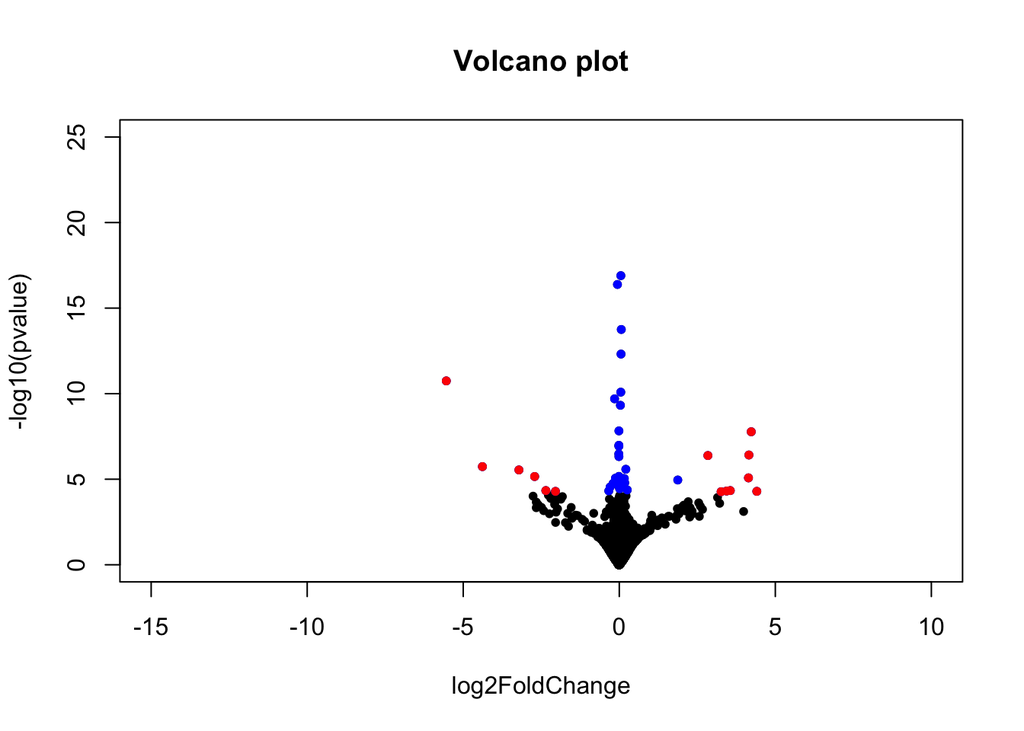

```r
#make volcano plot
#reset par
par(mfrow=c(1,1))
# Make a basic volcano plot
with(resLFC.T6, plot(log2FoldChange, -log10(pvalue), pch=20, main="Volcano plot", xlim=c(-15,10), ylim=c(0,25)))
with(subset(resLFC.T6, padj<.01 ), points(log2FoldChange, -log10(pvalue), pch=20, col="blue"))
with(subset(resLFC.T6, padj<.01 & abs(log2FoldChange)>2), points(log2FoldChange, -log10(pvalue), pch=20, col="red"))
```

## Drought vs. Pre-drought across different time points. (Here, pre-drought 48hr is set as reference.)

### Step 1

Create deseq2 object

```r
coldata$Condition_Time <- factor(coldata$Condition_Time, c("PreDrought_0hr", "PreDrought_6hr", "PreDrought_48hr",
                                                    "Drought_0hr", "Drought_6hr", "Drought_48hr"))

coldata$Condition_Time <- relevel(coldata$Condition_Time, ref = "PreDrought_48hr")


dds <- DESeqDataSetFromMatrix(countData = cts,
                              colData = coldata,
                              design= ~ Condition_Time + Site)
```

### Step 3a (Skip step 2, data exploration, because already performed above)

```r
###deifferential expression analysis###
dds <- DESeq(dds)
resultsNames(dds) # lists the coefficients
```

```
## [1] "Intercept"
## [2] "Condition_Time_PreDrought_0hr_vs_PreDrought_48hr"
## [3] "Condition_Time_PreDrought_6hr_vs_PreDrought_48hr"
## [4] "Condition_Time_Drought_0hr_vs_PreDrought_48hr"
## [5] "Condition_Time_Drought_6hr_vs_PreDrought_48hr"
## [6] "Condition_Time_Drought_48hr_vs_PreDrought_48hr"
## [7] "Site_Site2_vs_Site1"
## [8] "Site_Site3_vs_Site1"
```

```r
res.t48 <- results(dds, contrast = c("Condition_Time","Drought_48hr","PreDrought_48hr"))
plotMA(res, ylim=c(-40,40))
```

[output not shown]

```r
summary(res)
```

```
##
## out of 7414 with nonzero total read count
## adjusted p-value < 0.1
## LFC > 0 (up)       : 568, 7.7%
## LFC < 0 (down)     : 388, 5.2%
## outliers [1]       : 779, 11%
## low counts [2]     : 2865, 39%
## (mean count < 2)
## [1] see 'cooksCutoff' argument of ?results
## [2] see 'independentFiltering' argument of ?results
```

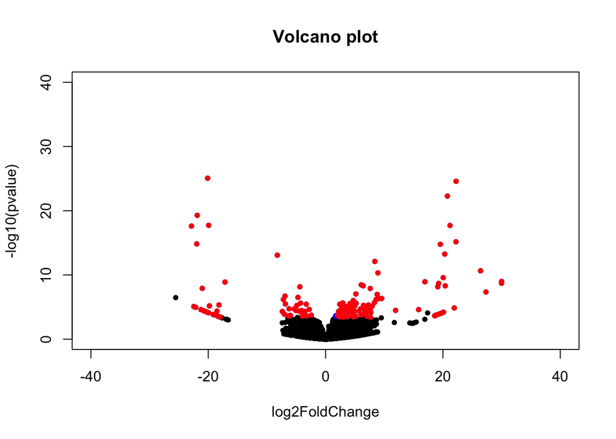

```r
#make volcano plot
#reset par
par(mfrow=c(1,1))
# Make a basic volcano plot
with(res.t48, plot(log2FoldChange, -log10(pvalue), pch=20, main="Volcano plot", xlim=c(-40,40), ylim=c(0,40)))

# Add colored points: blue if padj<0.01, red if log2FC>1 and padj<0.05)
with(subset(res.t48, padj<.01 ), points(log2FoldChange, -log10(pvalue), pch=20, col="blue"))
with(subset(res.t48, padj<.01 & abs(log2FoldChange)>2), points(log2FoldChange, -log10(pvalue), pch=20, col="red"))
```

### Step 3b Shrink effect size using apeglm. Notice spread of log2FC decreases without the extreme outliers of log2FC > 20.

```r
resLFC.t48 <- lfcShrink(dds, coef="Condition_Time_Drought_48hr_vs_PreDrought_48hr", type="apeglm")
```

```
## using 'apeglm' for LFC shrinkage. If used in published research, please cite:
##     Zhu, A., Ibrahim, J.G., Love, M.I. (2018) Heavy-tailed prior distributions for
##     sequence count data: removing the noise and preserving large differences.
##     Bioinformatics. https://doi.org/10.1093/bioinformatics/bty895
```

```r
resLFC.t48
```

```
## log2 fold change (MAP): Condition Time Drought 48hr vs PreDrought 48hr
## Wald test p-value: Condition Time Drought 48hr vs PreDrought 48hr
## DataFrame with 7414 rows and 5 columns
##             baseMean log2FoldChange     lfcSE    pvalue      padj
##            <numeric>      <numeric> <numeric> <numeric> <numeric>
## KO:K00001  85.720271    -0.01955514  0.581956  0.956976  0.982965
## KO:K00002   1.288149    -0.00965564  0.806976  0.975993        NA
## KO:K00003 356.903899     0.16542730  0.653602  0.675705  0.876052
## KO:K00004   2.052021     0.11445624  0.800740  0.946672        NA
## KO:K00005   0.295115    -0.03575833  0.807639  0.524355        NA
## ...              ...            ...       ...       ...       ...
## KO:K19784 119.271817      0.9998392  0.601943 0.0288971  0.179783
## KO:K19786   0.471282      0.0761709  0.810030 0.4806648        NA
## KO:K19788   2.042808      0.1266220  0.820130 0.2273621        NA
## KO:K19789   0.170424     -0.0531261  0.809173 0.5860590        NA
## KO:K19791   0.490408      0.0922093  0.812005 0.6682625        NA
```

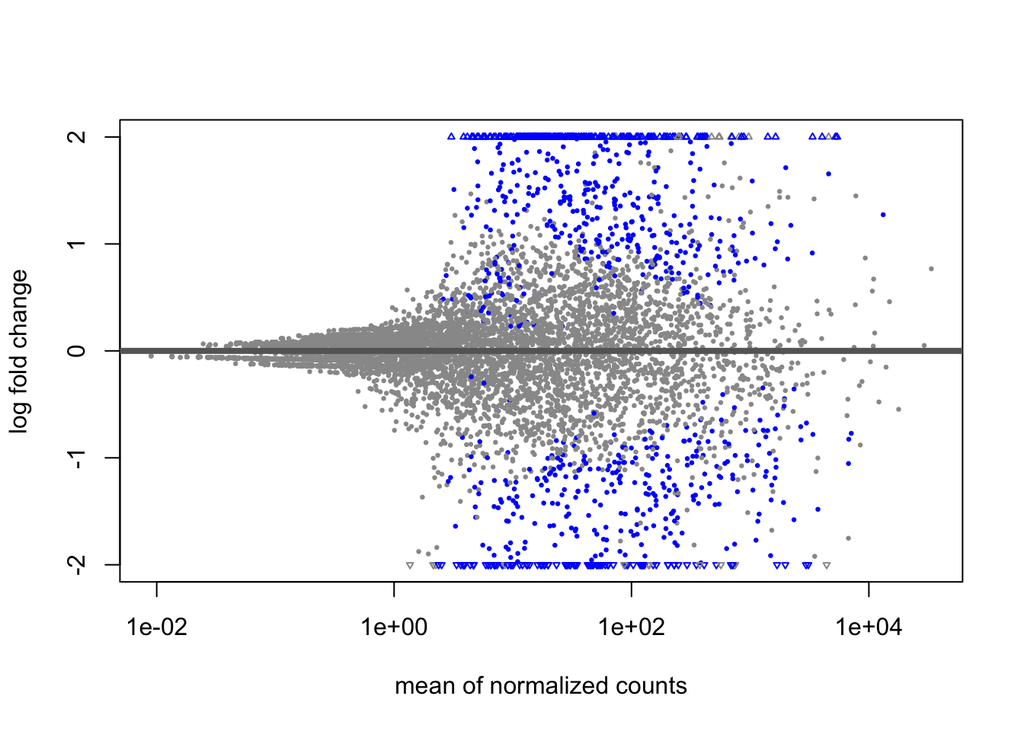

```r
plotMA(resLFC, ylim=c(-2,2))
```

```r
summary(resLFC.t48)
```

```
##
## out of 7414 with nonzero total read count
## adjusted p-value < 0.1
## LFC > 0 (up)       : 279, 3.8%
## LFC < 0 (down)     : 134, 1.8%
## outliers [1]       : 0, 0%
## low counts [2]     : 3594, 48%
## (mean count < 4)
## [1] see 'cooksCutoff' argument of ?results
## [2] see 'independentFiltering' argument of ?results
```

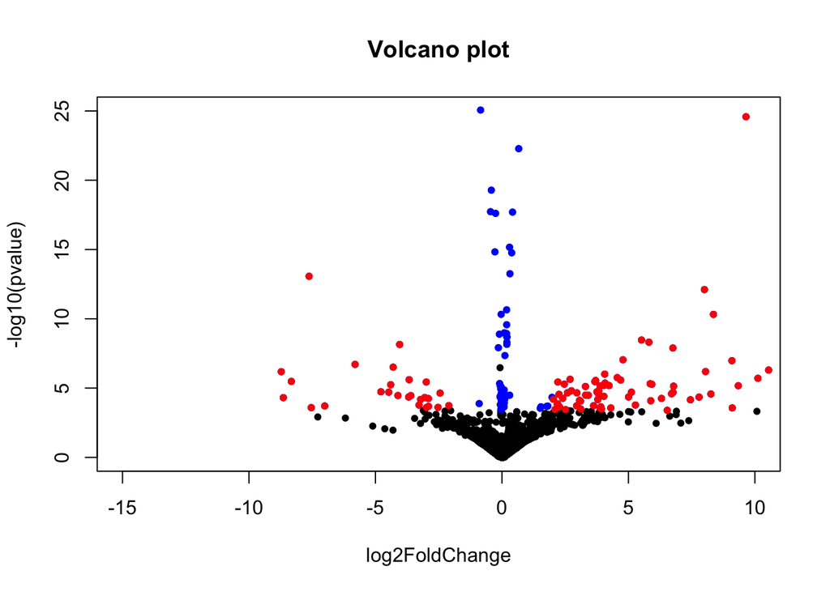

```r
#make volcano plot
#reset par
par(mfrow=c(1,1))
# Make a basic volcano plot
with(resLFC.t48, plot(log2FoldChange, -log10(pvalue), pch=20, main="Volcano plot", xlim=c(-15,10), ylim=c(0,25)))
with(subset(resLFC.t48, padj<.01 ), points(log2FoldChange, -log10(pvalue), pch=20, col="blue"))
with(subset(resLFC.t48, padj<.01 & abs(log2FoldChange)>2), points(log2FoldChange, -log10(pvalue), pch=20, col="red"))
```